# A. phalloides RNAseq: Mapping reads to the reference genome

Livia Oster

2025-08-05

### Data QC

First I uploaded the data to MSI from my laptop to filezilla. I am using the reference genome 10511_Aphal_PT_AllpathsLG_LINKS_jelly_pilon.fna, which is from the 72mAP mushroom and assembled from long-read sequencing.

## Rough pipeline

On Minnesota supercomputer (MSI):

- fastqc
- fastp trimming
- multiqc
- hisat
- featurecounts

Then transfer to laptop for DESeq2 in R.

I will use slurm arrays for fast processing on MSI. First I will generate a config file that specifies my samples, based on the fastq reads:

```r
# get filenames
filenames <- list.files("/Users/songs005/Library/CloudStorage/Box-Box/Drott_lab_shared_backup/Data/Aphalloides_rnaseq_for_leaderless/RAWTRANS/raw_data/201016_AHL2WCDSXY",pattern=".gz")

# extract sample ID column without underscores
Sample_ID <- unique(paste0(sapply(strsplit(filenames,split="_"), `[`, 1)))

SampleName <- unique(paste0(sapply(strsplit(filenames,split="_"), `[`, 1),
                            "_",
                            sapply(strsplit(filenames,split="_"), `[`, 2),
                            "_",
                            sapply(strsplit(filenames,split="_"), `[`, 3)))


# make empty config file
config <- as.data.frame(cbind(rep(1:length(SampleName)), SampleName,Sample_ID))

# add dir column to specify output dirs
colnames(config)[1] <- "ArrayTaskID"

# save output
write.table(config,"slurm_scripts/aphal_rnaseq_config.txt",row.names=FALSE)

# remember to transfer this config file to MSI and specify its filepath in the following slurm scripts.
```

### set up qc environment

Ensure config and data files are transferred to MSI. Log onto MSI. Set up environments & packages for analysis.

```bash
module load conda
conda --version
conda install -c bioconda fastp
conda install -c bioconda fastqc
conda install -c bioconda multiqc

#Next create an environment and install tools the tools
conda create --yes -n qc fastp fastqc multiqc

#To activate the env, in an interactive terminal you would type:
conda activate qc

# if you want to activate the environment in a bash script for slurm stuff, type:
source activate qc

# check versions!
fastp -version

# if -version fails, try -v or --version or -help or --help -h
fastqc -version
multiqc -version
```

#### run_fastqc.sh

```bash
#!/bin/bash -l
#SBATCH --job-name=fastqc_raw_trim    # Optional job name
#SBATCH --ntasks=1                      # Total number of tasks
#SBATCH --cpus-per-task=4
#SBATCH --mem=16g                     # max memory limit
#SBATCH --time=1:00:00                # Walltime limit
#SBATCH --mail-type=begin
#SBATCH --mail-type=end
#SBATCH --mail-user=songs005@umn.edu
#SBATCH --array=1-39                  # this will run one job for each sample

## This pulls from a tab-delimited file (array_config.txt) which has two columns.
## First column is labeled ArrayTaskID, second is Sample as the header and first row
## example:
## head(config.txt)
##  ArrayTaskID     SampleName Sample_ID
## 1           1 10745_S87_L001     10745

# define config file & variables
config=/scratch.global/songs005/aphal_rnaseq/aphal_rnaseq_config.txt

# sample names / prefixes for reads
samplename=$(awk -v ArrayTaskID=$SLURM_ARRAY_TASK_ID '$1==ArrayTaskID {print $2}' $config)

# location of raw reads
data=/scratch.global/songs005/aphal_rnaseq/raw_reads

# output dir
dir=/scratch.global/songs005/aphal_rnaseq/raw_reads/fastqc

# make output directory if it doesn't exist already
mkdir -p $dir

# then run QC on the raw reads
fastqc -o $dir ${data}/${samplename}_R1_001.fastq.gz
fastqc -o $dir ${data}/${samplename}_R2_002.fastq.gz
```

#### run_fastp.sh

This runs very fast - 3-5 min per read file typically

```bash
#!/bin/bash -l
#SBATCH --job-name=fastp_trim         # Optional job name
#SBATCH --ntasks=1                      # Total number of tasks
#SBATCH --cpus-per-task=4
#SBATCH --mem=16g                     # max memory limit
#SBATCH --time=0:20:00                # Walltime limit
#SBATCH --mail-type=begin
#SBATCH --mail-type=end
#SBATCH --mail-user=songs005@umn.edu
#SBATCH --array=1-39                  # this will run one job for each sample

# define config file & variables
config=/scratch.global/songs005/aphal_rnaseq/aphal_rnaseq_config.txt

# sample names / prefixes for reads
samplename=$(awk -v ArrayTaskID=$SLURM_ARRAY_TASK_ID '$1==ArrayTaskID {print $2}' $config)

# location of raw reads
data=/scratch.global/songs005/aphal_rnaseq/raw_reads

# output dir
dir=/scratch.global/songs005/aphal_rnaseq/trimmed_data

# make output directory
mkdir -p $dir

# run fastp; this will autodetect adapters
# -c is for base correction based on R1/R2 overlap
# -q is for qualified_quality_phred; minimal acceptable quality value
# -l is for length filtering options; reads shorter than this length will be discarded
# --detect_adapter_for_pe will specifically look for adapters; can result in a slightly more accurate & cleaner trim; slows down script a bit

fastp -c -q 10 -l 50 --detect_adapter_for_pe \
  -i $data/${samplename}_R1_001.fastq.gz \
  -I $data/${samplename}_R2_001.fastq.gz \
  -o $dir/${samplename}_R1_trim.fastq.gz \
  -O $dir/${samplename}_R2_trim.fastq.gz \
  --html $dir/${samplename}_trim.fastp.html \
  --json $dir/${samplename}_trim.fastp.json
```

#### run_trim_qc.sh

```bash
#!/bin/bash -l
#SBATCH --job-name=fastqc_trim        # Optional job name
#SBATCH --ntasks=1                      # Total number of tasks
#SBATCH --cpus-per-task=4
#SBATCH --mem=16g                     # max memory limit
#SBATCH --time=0:40:00                # Walltime limit
#SBATCH --mail-type=begin
#SBATCH --mail-type=end
#SBATCH --mail-user=songs005@umn.edu
#SBATCH --array=1-39                  # this will run one job for each sample

# define config file & variables
config=/scratch.global/songs005/aphal_rnaseq/aphal_rnaseq_config.txt

# sample names / prefixes for reads
samplename=$(awk -v ArrayTaskID=$SLURM_ARRAY_TASK_ID '$1==ArrayTaskID {print $2}' $config)

# location of reads
data=/scratch.global/songs005/aphal_rnaseq/trimmed_data

# output dir
dir=/scratch.global/songs005/aphal_rnaseq/trimmed_data/fastqc

# make output directory
mkdir -p $dir

# then run QC on the raw reads
fastqc -o $dir ${data}/${samplename}_R1_trim.fastq.gz
fastqc -o $dir ${data}/${samplename}_R2_trim.fastq.gz
```

After running fastq on the raw and trimmed reads, I ran multiqc on each directory to summarize fastQC results. The command for this is simply:

```bash
# load conda
module load conda
conda activate qc
# cd to dir with fastqc
cd /scratch.global/songs005/aphal_rnaseq/trimmed_data/fastqc
multiqc .

cd /scratch.global/songs005/aphal_rnaseq/raw_data/fastqc
multiqc .
```

I transferred the QC results to my laptop using filezilla.

### Hisat2

This took about 40 minutes to run hisat2 for one sample, and another 40 minutes or so to convert the sam to bam and index it.

```bash
# start interactive session
# this is to troubleshoot the code and see what works
srun -N 1 --ntasks-per-node=4 --mem=60gb --gres=gpu:a40:1 -t 2:00:00 -p interactive-gpu --tmp 50gb --pty bash

# load hisat2 and samtools
module load hisat2
hisat2 --version
# OUTPUT:
# /common/software/install/migrated/hisat2/2.1.0/bin/hisat2-align-s version 2.1.0
# 64-bit
# Built on swan.msi.umn.edu
# Tue Sep 19 14:45:21 CDT 2017
# Compiler: gcc version 4.4.7 20120313 (Red Hat 4.4.7-18) (GCC)

module load samtools
samtools --version
# OUTPUT:
# samtools 1.16.1
# Using htslib 1.16

# generate index - takes like 30 seconds
hisat2-build reff/10511_Aphal_PT_AllpathsLG_LINKS_jelly_pilon.fna reff/aphal_hisat_index

# test run on one sample - took about 40 min
hisat2 -x reff/aphal_hisat_index -1 trimmed_data/10708_S250_L002_trim_R1.fastq.gz -2 trimmed_data/10708_S250_L002_trim_R2.fastq.gz -S test.sam --phred33 --dta -t --rna-strandness RF

# convert to bam - took about 40 min
samtools view -uS test.sam | samtools sort -o test.bam
samtools index test.bam
```

#### hisat2.sh

```bash
#!/bin/bash -l
#SBATCH --job-name=hisat2         # Optional job name
#SBATCH --ntasks=1                # Total number of tasks
#SBATCH --cpus-per-task=4
#SBATCH --time=2:00:00            # Walltime limit
#SBATCH --mail-type=begin
#SBATCH --mail-type=end
#SBATCH --mail-user=songs005@umn.edu
#SBATCH --array=1-39              # this will run one job for each sample

# config file
config=/users/2/songs005/fastq_species_detector/aphal_config.txt
sample=$(awk -v ArrayTaskID=$SLURM_ARRAY_TASK_ID '$1==ArrayTaskID {print $2}' $config)

# set dirs
genomedir="/scratch.global/songs005/aphal_rnaseq/reff"
fastqdir="/home/mdrott/shared/liv/trimmed_data"
outdir="/scratch.global/songs005/aphal_rnaseq/17june_hisat2" # with hisat2 output
outdir2="/scratch.global/songs005/aphal_rnaseq/17june_hisat2_unmapped" # with hisat2 output

# make a specific dir for this job
#mkdir -p $outdir
mkdir -p $outdir/$sample

# load modules
module load hisat2
module load samtools

# build index - only needs to be done done once, can comment out
#hisat2-build $genomedir/10511_Aphal_PT_AllpathsLG_LINKS_jelly_pilon.fna $genomedir/aphal_hisat_index

# run hisat2
hisat2 -x $genomedir/aphal_hisat_index \
-1 $fastqdir/${sample}_trim_R1.fastq.gz \
-2 $fastqdir/${sample}_trim_R2.fastq.gz \
-S $outdir/$sample/${sample}.sam \
--phred33 \
--rna-strandness FR \
--dta \
--max-intronlen 3000 \
--un-conc $outdir/$sample \
-t # print walltime

# convert sam to bam format
samtools view -uS $outdir/$sample/${sample}.sam | samtools sort -o $outdir/$sample/${sample}.bam
samtools index $outdir/$sample/${sample}.bam
```

### Featurecounts

#### Subread installation

Next we run featurecounts from the subread package. To use featurecounts, I must install the subread package on MSI.

```bash
# exit qc environment
conda deactivate

# make new environment
conda create --name subread_env
conda activate subread_env

# install subread
conda install bioconda::subread
conda list
# OUTPUT BELOW:
# packages in environment at /users/2/songs005/.conda/envs/subread_env:
#
# Name                    Version                   Build  Channel
# _libgcc_mutex             0.1                        main
# _openmp_mutex             5.1                       1_gnu
# libgcc-ng                 11.2.0               h1234567_1
# libgomp                   11.2.0               h1234567_1
# subread                   2.0.1                h5bf99c6_1    bioconda
# zlib                      1.2.13               h5eee18b_1
```

#### featurecounts.sh

This script will only run after running the following on the console:

```bash
module load conda
conda activate subread_env
```

bash script below:

```bash
#!/bin/bash -l
#SBATCH --job-name=featurecounts            # Optional job name
#SBATCH --ntasks=1                          # Total number of tasks
#SBATCH --cpus-per-task=8
#SBATCH --mem=64g                           # max memory limit
#SBATCH --time=2:00:00                      # Walltime limit
#SBATCH --mail-type=begin
#SBATCH --mail-type=end
#SBATCH --mail-user=songs005@umn.edu
#SBATCH --array=1-39

config=/scratch.global/songs005/aphal_rnaseq/reff/config.txt
sample=$(awk -v ArrayTaskID=$SLURM_ARRAY_TASK_ID '$1==ArrayTaskID {print $2}' $config)

# set dirs
genomedir="/scratch.global/songs005/aphal_rnaseq/reff"
fastqdir="/scratch.global/songs005/aphal_rnaseq/trimmed_data"
outdir="/scratch.global/songs005/aphal_rnaseq/hisat2_output_msdins_array" # with star output
countdir="/scratch.global/songs005/aphal_rnaseq/hisat2_featurecounts_output_msdins" # for featureCounts output

# mkdir
mkdir -p $countdir
mkdir -p $countdir/$sample

featureCounts -T 20 \
        -a $genomedir/aphal_reff_with_msdins.gff3 \
        -o $countdir/$sample/${sample}_featurecounts.txt \
        --minOverlap 20 \
        -g Parent \
        -B \
        -C \
        -p \
        $outdir/$sample/${sample}.bam

# arguments for featureCounts
# -a genome annotation file
# -o output filename
# -g parses the attribute 'Parent' in the gff3 file
# -b include only fragments with both ends successfully aligned
# -C do not count chimeric fragments where two ends align to diff chr
# -p specify paired-end reads
# input file is listed last with no flag
```

### Fastqc on unmapped reads

Since Hisat2 output a file containing the unmapped reads for each sample, I ran fastqc on these as well to see if there were any sequence features that popped out.

```bash
#!/bin/bash -l
#SBATCH --job-name=1unmapped_fastqc         # Optional job name
#SBATCH --ntasks=1                          # Total number of tasks
#SBATCH --cpus-per-task=4
#SBATCH --mem=16g                           # max memory limit
#SBATCH --time=1:00:00                      # Walltime limit
#SBATCH --mail-type=begin
#SBATCH --mail-type=end
#SBATCH --mail-user=songs005@umn.edu
#SBATCH --array=1-39
config=/scratch.global/songs005/aphal_rnaseq/reff/unmapped_aphal_config.txt
sample=$(awk -v ArrayTaskID=$SLURM_ARRAY_TASK_ID '$1==ArrayTaskID {print $2}' $config)

# source activate qc

# location of unmapped reads

data=/scratch.global/songs005/aphal_rnaseq/hisat2_output_msdins_array_unmapp

# output dir
dir=/scratch.global/songs005/aphal_rnaseq/unmapped_fastqc

# make output directory
mkdir -p $dir

# then run QC on the raw reads
fastqc -o $dir/${sample} $data/*.1.fastq
fastqc -o $dir/${sample} $data/*.2.fastq
```

Next I switched to R to extract the overrepresented sequences from each unmapped file.

Fastqc automatically identifies duplicate sequences within each fasta, so I can extract these from the fastqc_data.txt files and then blast them or align them to a reference sequence.

```r
unmapp_path = "/Volumes/Liv/Lab_projects/Amanita_phalloides/MSI_outputs/unmapped_fastqc"

list_unmapped <- list.files(path=unmapp_path,recursive=TRUE,pattern="fastqc_data.txt",full.names=TRUE)

read_fastqc <- function(filename) {
  #filename=list_unmapped[1]
  filename_simp <- strsplit(filename, "/")[[1]][9]
  temp <- readLines(filename)

  # find row with overrepresented seqs

  temp <- as.data.frame(Map(function(i,j) read.table(text=temp[(i+1):(j-2)], sep='', header=FALSE), grep('>>Overrepresented', temp), grep('>>Adapter', temp)))

  # rename columns
  colnames(temp) <- c("Sequence","Count","Percentage","Possible_source")
  temp$header <- paste0(">",rownames(temp))

  # extract seqs as a fasta
  sequence_list <- as.vector(rbind(temp$header, temp$Sequence))

  # save temp as output in a folder
  outdir = "/Volumes/Liv/Lab_projects/Amanita_phalloides/MSI_outputs/unmapped_fastqc/overrep_stats/"

  outdir2 = "/Volumes/Liv/Lab_projects/Amanita_phalloides/MSI_outputs/unmapped_fastqc/overrep_seqs/"

  write.csv(temp, paste0(outdir,filename_simp,"_fastqc_overrep_stats.csv"),row.names=FALSE)
  write.table(sequence_list,
            file = paste0(outdir2, filename_simp, "_fastqc_overrep_seqs.fasta"),
            row.names = FALSE,
            col.names = FALSE,
            quote = FALSE)
  print(paste0("Extracted overrepresented sequences for: ",filename_simp))

}

# apply function to all entries on list
lapply(list_unmapped, read_fastqc)
```

```
## [1] "Extracted overrepresented sequences for: 10708_S250_L002_unmapped.1_fastqc"
## [1] "Extracted overrepresented sequences for: 10708_S250_L002_unmapped.2_fastqc"
## [1] "Extracted overrepresented sequences for: 10709_S251_L002_unmapped.1_fastqc"
## [1] "Extracted overrepresented sequences for: 10709_S251_L002_unmapped.2_fastqc"
## [1] "Extracted overrepresented sequences for: 10710_S252_L002_unmapped.1_fastqc"
## [1] "Extracted overrepresented sequences for: 10710_S252_L002_unmapped.2_fastqc"
## [1] "Extracted overrepresented sequences for: 10711_S253_L002_unmapped.1_fastqc"
## [1] "Extracted overrepresented sequences for: 10711_S253_L002_unmapped.2_fastqc"
## [1] "Extracted overrepresented sequences for: 10713_S254_L002_unmapped.1_fastqc"
## [1] "Extracted overrepresented sequences for: 10713_S254_L002_unmapped.2_fastqc"
## [1] "Extracted overrepresented sequences for: 10716_S255_L002_unmapped.1_fastqc"
## [1] "Extracted overrepresented sequences for: 10716_S255_L002_unmapped.2_fastqc"
## [1] "Extracted overrepresented sequences for: 10717_S256_L002_unmapped.1_fastqc"
## [1] "Extracted overrepresented sequences for: 10717_S256_L002_unmapped.2_fastqc"
## [1] "Extracted overrepresented sequences for: 10720_S257_L002_unmapped.1_fastqc"
```

[output cut: 63 more lines]

[output not shown]

[output cut: 178 more lines]

```
##
## [[74]]
## [1] "Extracted overrepresented sequences for: Quill1_S276_L002_unmapped.2_fastqc"
##
## [[75]]
## [1] "Extracted overrepresented sequences for: Tisza2_S277_L002_unmapped.1_fastqc"
##
## [[76]]
## [1] "Extracted overrepresented sequences for: Tisza2_S277_L002_unmapped.2_fastqc"
##
## [[77]]
## [1] "Extracted overrepresented sequences for: Tisza3_S278_L002_unmapped.1_fastqc"
##
## [[78]]
## [1] "Extracted overrepresented sequences for: Tisza3_S278_L002_unmapped.2_fastqc"
```

## Align sequences to 18s rRNA sequence

I took the top 75 overrepresented sequences of the unmapped reads for a couple samples and blasted them against the nt database at NCBI. Some aligned with a few bacterial species (which makes sense, as we performed RNA sequencing on wild mushrooms) but the majority of them aligned with the following gene:

Sequence ID: AY550243.1

Length: 5800

Amanita bisporigera intergenic spacer 2, partial sequence; 18S ribosomal RNA gene, internal transcribed spacer 1, 5.8S ribosomal RNA gene, internal transcribed spacer 2, and 28S ribosomal RNA gene, complete sequence; and intergenic spacer 1, partial sequence

They typically aligned to the last ~400 bp of this sequence. However, fastqc only includes 50 bp in their overrepresented sequence analysis. Each of my reads are 150 bp and paired end, so to be thorough, I decided to align all the unmapped reads from each sample to this ITS sequence. I ran the following code on the supercomputer at MSI:

```bash
module load bwa
cd /scratch.global/songs005/aphal_rnaseq/its18s

bwa index its18s.fna

bwa mem -t 10 its18s.fna ../hisat2_output_msdins_array_unmapp/10708_S250_L002/10708_S250_L002_unmapped.1.fastq ../hisat2_output_msdins_array_unmapp/10708_S250_L002/10708_S250_L002_unmapped.2.fastq
#Real time: 244.883 sec; CPU: 2140.206 sec

module load picard

java -jar /common/software/install/migrated/picard/2.25.6/picard.jar SortSam I=mAF.sam O=alignment.sorted.bam SORT_ORDER=coordinate
# Elapsed time: 10.92 minutes.

java -jar /common/software/install/migrated/picard/2.25.6/picard.jar BuildBamIndex INPUT=alignment.sorted.bam

#Elapsed time: 1.01 minutes.
rm mAF.sam
```

I then investigated the alignment in IGV, which confirmed this:

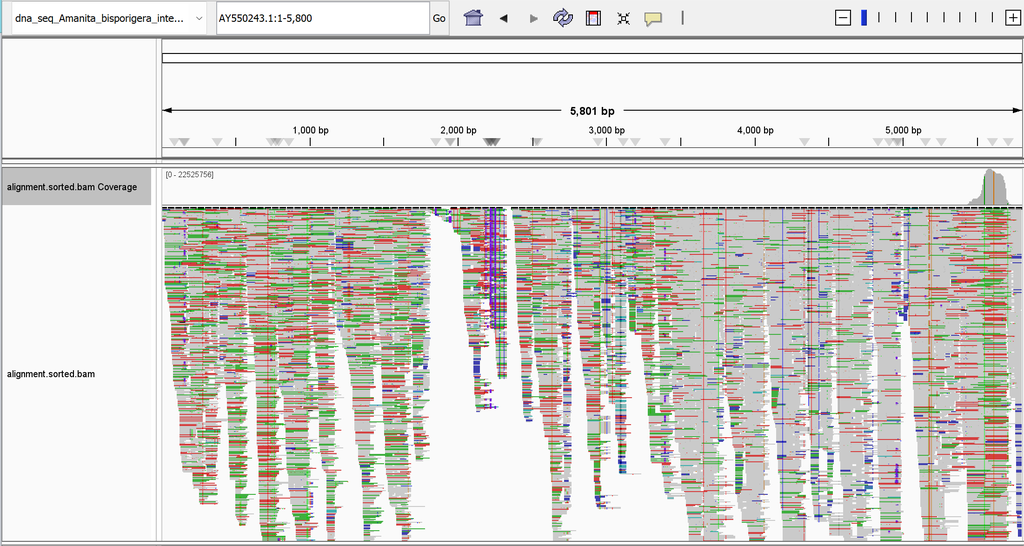

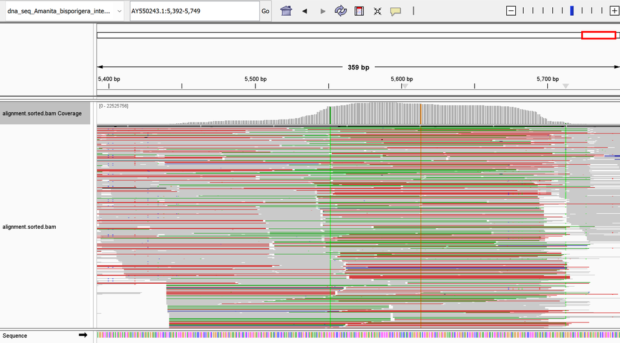